# Análisis de microarrays (PEC 1)

### Comparaciones múltiples

El siguiente paso es visualizar los genes que se expresan en varias comparaciones y los que no. En este estudio, interesa saber qué genes están expresados de manera diferencial en varias comparaciones o qué genes cambian en más de una comparación.

```
##        D3vsD7.NONE D3vsD11.NONE D3.NONEvs1 D7.01vs1 D7.01vs10 D7vsD11.1
## Down             9           83        638        0        29        25
## NotSig        4595         4417       3534     4630      4559      4585
## Up              26          130        458        0        42        20
```

A continuación, se muestran unos diagramas de Venn que muestran los genes compartidos entre diferentes comparaciones, con un límite de FDR<0.1 y logFC>1.

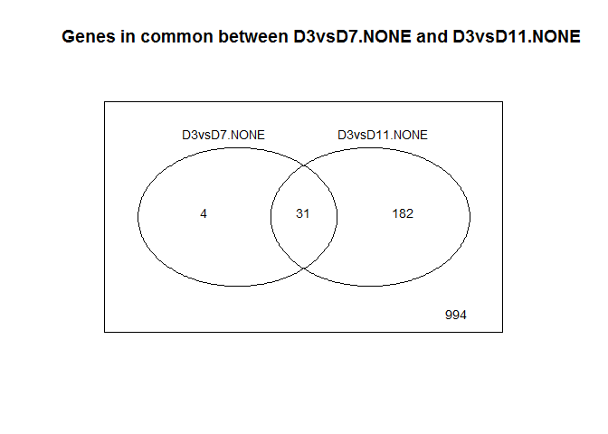

Figura 31. Diagrama de Venn entre las comparaciones D3vsD7.NONE y D3vsD11.NONE

En este caso, hay 31 genes coincidentes entre ambas comparaciones. En la comparación D3vsD7.NONE hay 4 genes no expresados en la comparación D3vsD11.NONE y en la comparación D3vsD11.NONE hay 182 genes no expresados en la comparación D3vsD7.NONE.

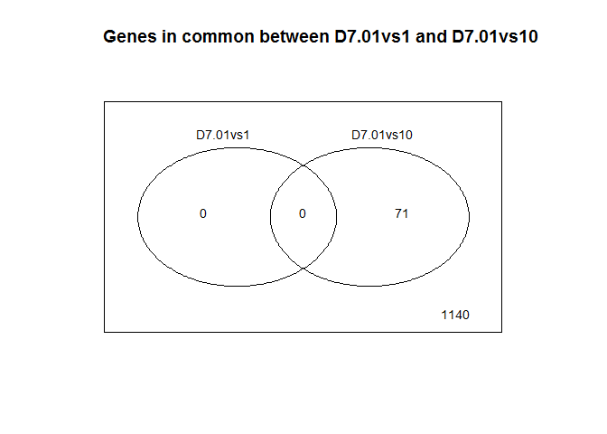

Figura 32. Diagrama de Venn entre las comparaciones D7.01vs1 y D7.01vs10

En este caso, hay 71 genes que están expresados en la comparación D7.01vs10 que no están expresados en la comparación D7.01vs1.

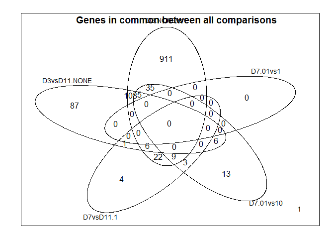

### Heatmap

A continuación, se realizan los gráficos *heatmaps*, los cuales muestran los genes diferencialmente expresados, regulados tanto a la alza como a la baja. Para ello se usa una paleta de colores que resalta estos valores.

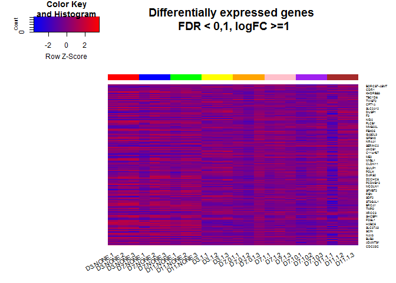

Figura 34. Heatmap

Los *heatmaps* también pueden mostrar los valores agrupados jerárquicamente en genes (filas) o muestras (columnas) para así encontrar aquellos genes con patrones comunes de variación y agruparlos en grupos.

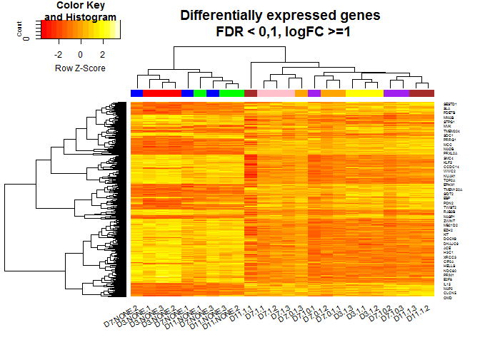

Figura 35. Heatmap con valores ordenados jerárquicamente

### Significado biológico de los resultados

El siguiente paso es, una vez se tiene la lista de genes seleccionados como diferencialmente expresados, establecer si estos genes tienen funciones parecidas o pertenecen a un mismo proceso biológico o vía molecular. Esto ayudará a la comprensión del problema biológico del estudio.

Para ello, se usa el paquete *clusterProfiler*, el cual implementa métodos para analizar y visualizar perfiles funcionales del gen o del clúster de genes.

Para cada comparación, se consideran los objetos *TopAnnotated* pues incluyen el listado de genes y el valor logFC.

Los datos pertenecen a la especie *Homo sapiens*, así que se instala y carga la anotación *org.Hs.eg.db*.

El primer paso es preparar la lista de genes. Para ello, se seleccionan los valores logFC, se da nombre a los genes, se eliminan los valores nulos (NA) y se ordenan en orden descendente.

A continuación, se utiliza la función *gseGO* del paquete para realizar el enriquecimiento del conjunto de genes.

El último paso es la visualización de los resultados a través de gráficos de puntos (dotplots) y mapas de enriquecimiento. Los mapas de enriquecimiento organizan los datos enriquecidos en forma de red que conecta conjuntos de genes superpuestos. De esta manera, los conjuntos de genes que se superponen tienden a agruparse, hecho que permite identificar módulos funcionales.

A continuación, pueden observarse los distintos gráficos de las diferentes comparaciones realizadas en el estudio.

**Comparación D3vsD7.NONE**

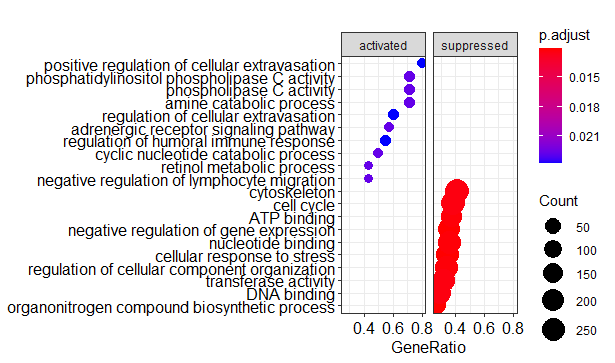

Figura 36. Dotplot comparación D3vsD7.NONE

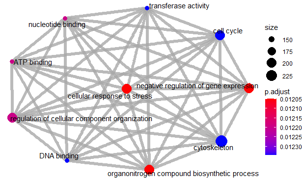

Figura 37. Mapa de enriquecimiento comparación D3vsD7.NONE

**Comparación D3vsD11.NONE**

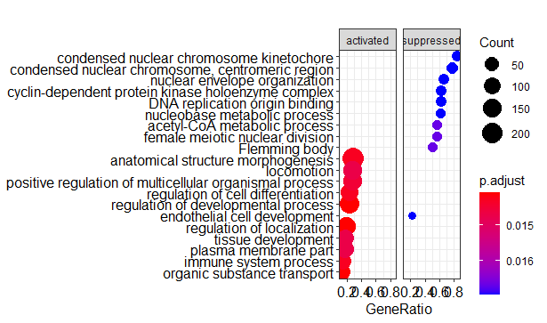

Figura 38. Dotplot comparación D3vsD11.NONE

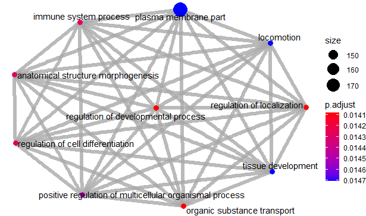

Figura 39. Mapa de enriquecimiento comparación D3vsD11.NONE

**Comparación D3.NONevs1**

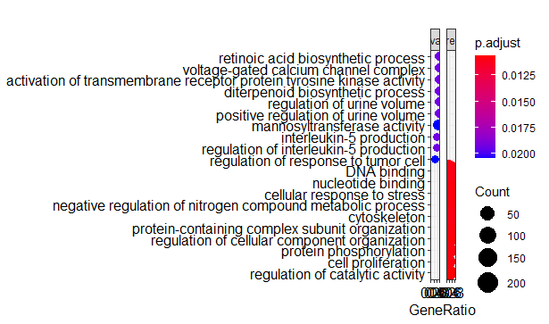

Figura 40. Dotplot comparación D3.NONEvs1

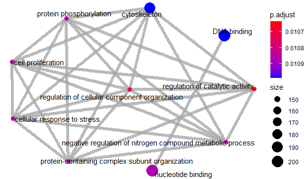

Figura 41. Mapa de enriquecimiento comparación D3.NONEvs1

**Comparación D7.01vs1**

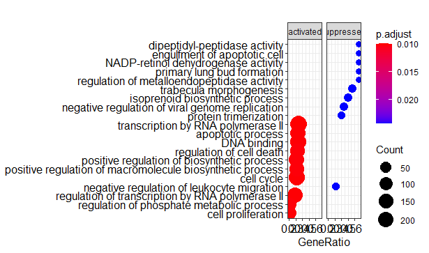

Figura 42. Dotplot comparación D7.01vs1

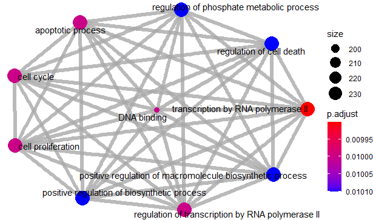

Figura 43. Mapa de enriquecimiento comparación D7.01vs1

**Comparación D7.01vs10**

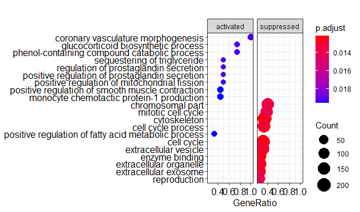

Figura 44. Dotplot comparación D7.01vs10

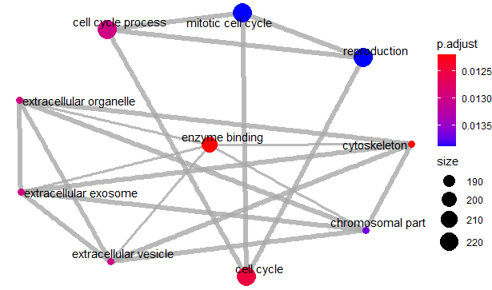

Figura 45. Mapa de enriquecimiento comparación D7.01vs10

**Comparación D7vsD11.1**

[figure not shown]

Figura 46. Dotplot comparación D7vsD11.1

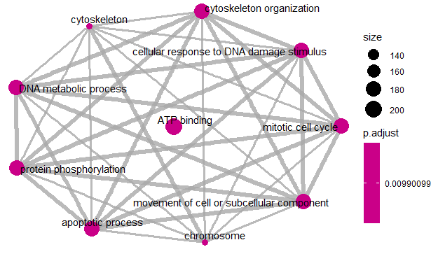

Figura 47. Mapa de enriquecimiento comparación D7vsD11.1

# RESULTADOS

Los genes que han resultado tener una expresión más diferencial (considerando que son aquellos que muestran un valor p más pequeño) en cada comparación son los siguientes:

- **Comparación D3vsD7.NONE**: RGS2 (regulator of G protein signaling 2), ADH1B (alcohol dehydrogenase 1B (class I), beta polypeptide), APCDD1 (APC down-regulated 1), ACTC1 (actin alpha cardiac muscle 1), WNT2B (Wnt family member 2B), PTGIS (prostaglandin I2 synthase), BDKRB2 (bradykinin receptor B2), FAXDC2 (fatty acid hydroxylase domain containing 2), PDGFD (platelet derived growth factor D) y TGFBI (transforming growth factor beta induced).
- **Comparación D3vsD11.NONE**: PTGIS (prostaglandin I2 synthase), RGS2 (regulator of G protein signaling 2), SERPINF1 (serpin family F member 1), ADH1B (alcohol dehydrogenase 1B (class I), beta polypeptide), TGFBI (transforming growth factor beta induced), PDGFD (platelet derived growth factor D), APOD (apolipoprotein D), WNT2B (Wnt family member 2B), KRT34 (keratin 34) y BDKRB2 (bradykinin receptor B2).
- **Comparación D3.NONEvs1**: RGS2 (regulator of G protein signaling 2), IGFBP1 (insulin like growth factor binding protein 1), PRL (prolactin), MYOCD (myocardin), RASL11B (RAS like family 11 member B), SST (somatostatin), ABCA8 (ATP binding cassette subfamily A member 8), CRISPLD2 (cysteine rich secretory protein LCCL domain containing 2), FOXO1 (forkhead box O1) y FAM167A (family with sequence similarity 167 member A).
- **Comparación D7.01vs1**: WNT4 (Wnt family member 4), WNT2B (Wnt family member 2B), TMEM171 (transmembrane protein 171), MGP (matrix Gla protein), CXCL8 (C-X-C motif chemokine ligand 8), IL18R1 (interleukin 18 receptor 1), APOL2 (apolipoprotein L2), EDN1 (endothelin 1), IL7R (interleukin 7 receptor) y REN (renin).
- **Comparación D7.01vs10**: TREM1 (triggering receptor expressed on myeloid cells 1), CCL2 (C-C motif chemokine ligand 2), TMEM171 (transmembrane protein 171), ANOS1 (anosmin 1), SLC7A8 (solute carrier family 7 member 8), KDR (kinase insert domain receptor), WNT4 (Wnt family member 4), MEST (mesoderm specific transcript), GPX3 (glutathione peroxidase 3) y IGFBP1 (insulin like growth factor binding protein 1).
- **Comparación D7vsD11.1**: ACTA2 (actin alpha 2, smooth muscle), TAGLN (transgelin), ACKR3 (atypical chemokine receptor 3), DIO2 (iodothyronine deiodinase 2), OR1N1 (olfactory receptor family 1 subfamily N member 1), WNT4 (Wnt family member 4), PCSK5 (proprotein convertase subtilisin/kexin type 5), LIMS2 (LIM zinc finger domain containing 2), RRM2 (ribonucleotide reductase regulatory subunit M2) y ZNF474 (zinc finger protein 474).

# DISCUSIÓN

# APÉNDICE

**Preparación del entorno**

```r
setwd(".")
dir.create("data")
dir.create("results")
```

**Preparación de los datos para el análisis**

```r
targets <- read.csv2("./data/targets.csv", header = TRUE, sep = ";")
```

```r
knitr::kable(
  targets, booktabs = TRUE,
  caption = 'Content of the targets file used for the current analysis')
```

```r
library(oligo)
celFiles <- list.celfiles("./data", full.names = TRUE)
library(Biobase)
my.targets <-read.AnnotatedDataFrame(file.path("./data","targets.csv"),
                                     header = TRUE, row.names = 1,
                                     sep=";")
rawData <- read.celfiles(celFiles, phenoData = my.targets)
```

```r
my.targets@data$ShortName->rownames(pData(rawData))
colnames(rawData) <-rownames(pData(rawData))
head(rawData)
```

**Instalación de paquetes**

```r
if (!requireNamespace("BiocManager", quietly = TRUE))
  install.packages("BiocManager")
BiocManager::install()
```

```r
install.packages("knitr")
install.packages("colorspace")
install.packages("gplots")
install.packages("ggplot2")
install.packages("ggrepel")
install.packages("htmlTable")
install.packages("prettydoc")
install.packages("devtools")
install.packages("BiocManager")
BiocManager::install("oligo")
BiocManager::install("pd.mogene.2.1.st")
BiocManager::install("arrayQualityMetrics")
BiocManager::install("pvca")
BiocManager::install("limma")
BiocManager::install("genefilter")
BiocManager::install("clariomdhumantranscriptcluster.db")
BiocManager::install("annotate")
BiocManager::install("org.Hs.eg.db")
BiocManager::install("clusterProfiler")
```

**Control de calidad de los datos**

```r
library(arrayQualityMetrics)
arrayQualityMetrics(rawData,force=TRUE)
```

```r
library(ggplot2)
library(ggrepel)
plotPCA3 <- function (datos, labels, factor, title, scale,colores, size = 1.5, glineas = 0.25) {
  data <- prcomp(t(datos),scale=scale)
  dataDf <- data.frame(data$x)
  Group <- factor
  loads <- round(data$sdev^2/sum(data$sdev^2)*100,1)
  p1 <- ggplot(dataDf,aes(x=PC1, y=PC2)) +
    theme_classic() +
    geom_hline(yintercept = 0, color = "gray70") +
    geom_vline(xintercept = 0, color = "gray70") +
    geom_point(aes(color = Group), alpha = 0.55, size = 3) +
    coord_cartesian(xlim = c(min(data$x[,1])-5,max(data$x[,1])+5)) +
    scale_fill_discrete(name = "Group")
  p1 + geom_text_repel(aes(y = PC2 + 0.25, label = labels),segment.size = 0.25, size = size) +
    labs(x = c(paste("PC1",loads[1],"%")),y=c(paste("PC2",loads[2],"%"))) +
    ggtitle(paste("Principal Component Analysis for: ",title,sep=" "))+
    theme(plot.title = element_text(hjust = 0.5)) +
    scale_color_manual(values=colores)
  }
```

```r
plotPCA3(exprs(rawData), labels = targets$ShortName, factor = targets$Group,
         title="Raw data", scale = FALSE, size = 3,
         colores = c("red", "blue", "green", "yellow","orange","pink","purple","brown"))
```

```r
tiff("figures/PCA_RawData.tiff", res = 200, width = 4.5, height = 4, units = 'in')
plotPCA3(exprs(rawData), labels = targets$ShortName, factor = targets$Group,
         title="Raw data", scale = FALSE, size = 2,
         colores = c("red", "blue", "green", "yellow","orange","pink","purple","brown"))
dev.off()
```

```r
boxplot(rawData, cex.axis=0.5, las=2,  which="all",
        col = c(rep("red", 3), rep("blue", 3), rep("green", 3), rep("yellow", 3), rep("orange", 3), rep("pink", 3), rep("purple", 3), rep("brown", 3)),
        main="Distribution of raw intensity values")
```

**Normalización de los datos**

```r
eset_rma <- rma(rawData)
```

**Control de calidad de los datos normalizados**

```r
arrayQualityMetrics(eset_rma, outdir = file.path("./results", "QCDir.Norm"), force=TRUE)
```

```r
plotPCA3(exprs(eset_rma), labels = targets$ShortName, factor = targets$Group,
         title="Normalized data", scale = FALSE, size = 3,
         colores = c("red", "blue", "green",  "yellow", "orange", "pink", "purple", "brown"))
```

```r
boxplot(eset_rma, cex.axis=0.5, las=2,  which="all",
        col = c(rep("red", 3), rep("blue", 3), rep("green", 3), rep("yellow", 3), rep("orange", 3), rep("pink", 3), rep("purple", 3), rep("brown", 3)),
        main="Boxplot for arrays intensity: Normalized Data")
```

**Detección de “batch factors”**

```r
library(pvca)
pData(eset_rma) <- targets
pct_threshold <- 0.6
batch.factors <- c("Timing", "Levels")
pvcaObj <- pvcaBatchAssess (eset_rma, batch.factors, pct_threshold)
```

```r
bp <- barplot(pvcaObj$dat, xlab = "Effects",
              ylab = "Weighted average proportion variance",
              ylim= c(0,1.1),col = c("mediumorchid"), las=2,
              main="PVCA estimation")
axis(1, at = bp, labels = pvcaObj$label, cex.axis = 0.55, las=2)
values = pvcaObj$dat
new_values = round(values , 3)
text(bp,pvcaObj$dat,labels = new_values, pos=3, cex = 0.5)
```

**Detección de genes más variables**

```r
sds <- apply (exprs(eset_rma), 1, sd)
sdsO<- sort(sds)
plot(1:length(sdsO), sdsO, main="Distribution of variability for all genes",
     sub="Vertical lines represent 90% and 95% percentiles",
     xlab="Gene index (from least to most variable)", ylab="Standard deviation")
abline(v=length(sds)*c(0.9,0.95))
```

**Filtraje de genes menos variables**

```r
library(genefilter)
if (!requireNamespace("BiocManager", quietly = TRUE))
    install.packages("BiocManager")
BiocManager::install("clariomdhumantranscriptcluster.db")
library(clariomdhumantranscriptcluster.db)
annotation(eset_rma) <- "clariomdhumantranscriptcluster.db"
filtered <- nsFilter(eset_rma,
                     require.entrez = TRUE, remove.dupEntrez = TRUE,
                     var.filter=TRUE, var.func=IQR, var.cutoff=0.75,
                     filterByQuantile=TRUE, feature.exclude = "^AFFX")
```

```r
library(genefilter)
library(clariomdhumantranscriptcluster.db)
annotation(eset_rma) <- "clariomdhumantranscriptcluster.db"
filtered <- nsFilter(eset_rma,
                     require.entrez = TRUE, remove.dupEntrez = TRUE,
                     var.filter=TRUE, var.func=IQR, var.cutoff=0.75,
                     filterByQuantile=TRUE, feature.exclude = "^AFFX")
```

```r
print(filtered$filter.log)
```

```r
eset_filtered <-filtered$eset
```

**Guardar datos normalizados y filtrados**

```r
write.csv(exprs(eset_rma), file="./results/normalized.Data.csv")
write.csv(exprs(eset_filtered), file="./results/normalized.Filtered.Data.csv")
save(eset_rma, eset_filtered, file="./results/normalized.Data.Rda")
```

**Matriz de diseño**

```r
if (!exists("eset_filtered")) load (file="./results/normalized.Data.Rda")
```

```r
library(limma)
designMat<- model.matrix(~0+Group, pData(eset_filtered))
colnames(designMat) <- c("D11.1", "D11.NONE", "D3.1", "D3.NONE", "D7.01", "D7.1", "D7.10", "D7.NONE")
print(designMat)
```

**Matriz de contraste**

```r
cont.matrix <- makeContrasts (D3vsD7.NONE = D7.NONE-D3.NONE,
                              D3vsD11.NONE = D11.NONE-D3.NONE,
                              D3.NONEvs1 = D3.1-D3.NONE,
                              D7.01vs1 = D7.1-D7.01,
                              D7.01vs10 = D7.10-D7.01,
                              D7vsD11.1 = D11.1-D7.1,
                              levels=designMat)
print(cont.matrix)
```

**Estimación del modelo y selección de genes**

```r
library(limma)
fit<-lmFit(eset_filtered, designMat)
fit.main<-contrasts.fit(fit, cont.matrix)
fit.main<-eBayes(fit.main)
class(fit.main)
```

**Obtención de listados de los genes diferencialmente expresados**

```r
topTab_D3vsD7.NONE <- topTable (fit.main, number=nrow(fit.main), coef="D3vsD7.NONE", adjust="fdr")
head(topTab_D3vsD7.NONE)
```

```r
topTab_D3vsD11.NONE <- topTable (fit.main, number=nrow(fit.main), coef="D3vsD11.NONE", adjust="fdr")
head(topTab_D3vsD11.NONE)
```

```r
topTab_D3.NONEvs1 <- topTable (fit.main, number=nrow(fit.main), coef="D3.NONEvs1", adjust="fdr")
head(topTab_D3.NONEvs1)
```

```r
topTab_D7.01vs1 <- topTable (fit.main, number=nrow(fit.main), coef="D7.01vs1", adjust="fdr")
head(topTab_D7.01vs1)
```

```r
topTab_D7.01vs10 <- topTable (fit.main, number=nrow(fit.main), coef="D7.01vs10", adjust="fdr")
head(topTab_D7.01vs10)
```

```r
topTab_D7vsD11.1 <- topTable (fit.main, number=nrow(fit.main), coef="D7vsD11.1", adjust="fdr")
head(topTab_D7vsD11.1)
```

**Anotación de genes**

```r
annotatedTopTable <- function(topTab, anotPackage)
  {
  topTab <- cbind(PROBEID=rownames(topTab), topTab)
  myProbes <- rownames(topTab)
  thePackage <- eval(parse(text = anotPackage))
  geneAnots <- select(thePackage, myProbes, c("SYMBOL", "ENTREZID", "GENENAME"))
  annotatedTopTab<- merge(x=geneAnots, y=topTab, by.x="PROBEID", by.y="PROBEID")
  return(annotatedTopTab)
  }
```

```r
topAnnotated_D3vsD7.NONE <- annotatedTopTable(topTab_D3vsD7.NONE, anotPackage="clariomdhumantranscriptcluster.db")
topAnnotated_D3vsD11.NONE <- annotatedTopTable(topTab_D3vsD11.NONE, anotPackage="clariomdhumantranscriptcluster.db")
topAnnotated_D3.NONEvs1 <- annotatedTopTable(topTab_D3.NONEvs1, anotPackage="clariomdhumantranscriptcluster.db")
topAnnotated_D7.01vs1 <- annotatedTopTable(topTab_D7.01vs1, anotPackage="clariomdhumantranscriptcluster.db")
topAnnotated_D7.01vs10 <- annotatedTopTable(topTab_D7.01vs10, anotPackage="clariomdhumantranscriptcluster.db")
topAnnotated_D7vsD11.1 <- annotatedTopTable(topTab_D7vsD11.1, anotPackage="clariomdhumantranscriptcluster.db")

write.csv(topAnnotated_D3vsD7.NONE,file="./results/topAnnotated_D3vsD7.NONE.csv")
write.csv(topAnnotated_D3vsD11.NONE,file="./results/topAnnotated_D3vsD11.NONE.csv")
write.csv(topAnnotated_D3.NONEvs1,file="./results/topAnnotated_D3.NONEvs1.csv")
write.csv(topAnnotated_D7.01vs1,file="./results/topAnnotated_D7.01vs1.csv")
write.csv(topAnnotated_D7.01vs10,file="./results/topAnnotated_D7.01vs10.csv")
write.csv(topAnnotated_D7vsD11.1,file="./results/topAnnotated_D7vsD11.1.csv")
```

**Visualización de la expresión diferencial**

```r
library(clariomdhumantranscriptcluster.db)
geneSymbols <- select(clariomdhumantranscriptcluster.db, rownames(fit.main), c("SYMBOL"))
SYMBOLS<- geneSymbols$SYMBOL
volcanoplot(fit.main, coef=1, highlight=4, names=SYMBOLS,
            main=paste("Differentially expressed genes",
                       colnames(cont.matrix)[1], sep="\n"))
abline(v=c(-1,1))
```

```r
volcanoplot(fit.main, coef=2, highlight=4, names=SYMBOLS,
            main=paste("Differentially expressed genes",
                       colnames(cont.matrix)[2], sep="\n"))
```

```r
volcanoplot(fit.main, coef=3, highlight=4, names=SYMBOLS,
            main=paste("Differentially expressed genes",
                       colnames(cont.matrix)[3], sep="\n"))
```

```r
volcanoplot(fit.main, coef=4, highlight=4, names=SYMBOLS,
            main=paste("Differentially expressed genes",
                       colnames(cont.matrix)[4], sep="\n"))
```

```r
volcanoplot(fit.main, coef=5, highlight=4, names=SYMBOLS,
            main=paste("Differentially expressed genes",
                       colnames(cont.matrix)[5], sep="\n"))
```

```r
volcanoplot(fit.main, coef=6, highlight=4, names=SYMBOLS,
            main=paste("Differentially expressed genes",
                       colnames(cont.matrix)[6], sep="\n"))
```

**Comparaciones múltiples**

```r
library(limma)
res<-decideTests(fit.main, method="separate", adjust.method="fdr", p.value=0.1, lfc=1)
```

```r
sum.res.rows<-apply(abs(res),1,sum)
res.selected<-res[sum.res.rows!=0,]
print(summary(res))
```

```r
vennDiagram (res.selected[,1:2], cex=0.9)
title("Genes in common between the three comparisons\n Genes selected with FDR < 0.1 and logFC > 1")
```

```r
vennDiagram (res.selected[,4:5], cex=0.9)
title("Genes in common between the three comparisons\n Genes selected with FDR < 0.1 and logFC > 1")
```

```r
vennDiagram (res.selected[,2:6], cex=0.9)
title("Genes in common between all comparisons")
```

**Heatmaps**

```r
probesInHeatmap <- rownames(res.selected)
HMdata <- exprs(eset_filtered)[rownames(exprs(eset_filtered)) %in% probesInHeatmap,]
geneSymbols <- select(clariomdhumantranscriptcluster.db, rownames(HMdata), c("SYMBOL"))
SYMBOLS<- geneSymbols$SYMBOL
rownames(HMdata) <- SYMBOLS
write.csv(HMdata, file = file.path("./results/data4Heatmap.csv"))
```

```r
my_palette <- colorRampPalette(c("blue", "red"))(n = 299)
library(gplots)
heatmap.2(HMdata,
          Rowv = FALSE,
          Colv = FALSE,
          main = "Differentially expressed genes \n FDR < 0,1, logFC >=1",
          scale = "row",
          col = my_palette,
          sepcolor = "white",
          sepwidth = c(0.05,0.05),
          cexRow = 0.5,
          cexCol = 0.9,
          key = TRUE,
          keysize = 1.5,
          density.info = "histogram",
          ColSideColors = c(rep("red",3),rep("blue",3), rep("green",3), rep("yellow",3), rep("orange",3), rep("pink",3), rep("purple",3), rep("brown",3)),
          tracecol = NULL,
          dendrogram = "none",
          srtCol = 30)
```

```r
heatmap.2(HMdata,
          Rowv = TRUE,
          Colv = TRUE,
          dendrogram = "both",
          main = "Differentially expressed genes \n FDR < 0,1, logFC >=1",
          scale = "row",
          ol = my_palette,
          sepcolor = "white",
          sepwidth = c(0.05,0.05),
          cexRow = 0.5,
          cexCol = 0.9,
          key = TRUE,
          keysize = 1.5,
          ensity.info = "histogram",
          ColSideColors = c(rep("red",3),rep("blue",3), rep("green",3), rep("yellow",3), rep("orange",3), rep("pink",3), rep("purple",3), rep("brown",3)),
          tracecol = NULL,
          srtCol = 30)
```

**Significado biológico de los resultados**

```r
BiocManager::install("clusterProfiler")
BiocManager::install("pathview")
BiocManager::install("enrichplot")
library(clusterProfiler)
library(enrichplot)
library(ggplot2)
```

```r
organism = "org.Hs.eg.db"
BiocManager::install(organism, character.only = TRUE)
library(organism, character.only = TRUE)
```

```r
original_gene_list1 <- topAnnotated_D3.NONEvs1$logFC
names(original_gene_list1) <- topAnnotated_D3.NONEvs1$GENENAME
gene_list1 <- na.omit(original_gene_list1)
gene_list1 = sort(gene_list1, decreasing = TRUE)
```

```r
gse1 <- gseGO(geneList=gene_list1,
             ont ="ALL",
             keyType = "GENENAME",
             nPerm = 100,
             minGSSize = 3,
             maxGSSize = 800,
             pvalueCutoff = 0.05,
             verbose = TRUE,
             OrgDb = organism,
             pAdjustMethod = "none")
```

```r
require(DOSE)
dotplot(gse1, showCategory=10, split=".sign") + facet_grid(.~.sign)
emapplot(gse1, showCategory = 10)
```

```r
original_gene_list2 <- topAnnotated_D3vsD11.NONE$logFC
names(original_gene_list2) <- topAnnotated_D3vsD11.NONE$GENENAME
gene_list2 <- na.omit(original_gene_list2)
gene_list2 = sort(gene_list2, decreasing = TRUE)
```

```r
gse2 <- gseGO(geneList=gene_list2,
             ont ="ALL",
             keyType = "GENENAME",
             nPerm = 100,
             minGSSize = 3,
             maxGSSize = 800,
             pvalueCutoff = 0.05,
             verbose = TRUE,
             OrgDb = organism,
             pAdjustMethod = "none")
```

```r
emapplot(gse2, showCategory = 10)
dotplot(gse2, showCategory=10, split=".sign") + facet_grid(.~.sign)
```

```r
original_gene_list3 <- topAnnotated_D3vsD7.NONE$logFC
names(original_gene_list3) <- topAnnotated_D3vsD7.NONE$GENENAME
gene_list3 <- na.omit(original_gene_list3)
gene_list3 = sort(gene_list3, decreasing = TRUE)
```

```r
gse3 <- gseGO(geneList=gene_list3,
             ont ="ALL",
             keyType = "GENENAME",
             nPerm = 100,
             minGSSize = 3,
             maxGSSize = 800,
             pvalueCutoff = 0.05,
             verbose = TRUE,
             OrgDb = organism,
             pAdjustMethod = "none")
```

```r
dotplot(gse3, showCategory=10, split=".sign") + facet_grid(.~.sign)
emapplot(gse3, showCategory = 10)
```

```r
original_gene_list4 <- topAnnotated_D7.01vs1$logFC
names(original_gene_list4) <- topAnnotated_D7.01vs1$GENENAME
gene_list4 <- na.omit(original_gene_list4)
gene_list4 = sort(gene_list4, decreasing = TRUE)
```

```r
gse4 <- gseGO(geneList=gene_list4,
             ont ="ALL",
             keyType = "GENENAME",
             nPerm = 100,
             minGSSize = 3,
             maxGSSize = 800,
             pvalueCutoff = 0.05,
             verbose = TRUE,
             OrgDb = organism,
             pAdjustMethod = "none")
```

```r
dotplot(gse4, showCategory=10, split=".sign") + facet_grid(.~.sign)
emapplot(gse4, showCategory = 10)
```

```r
original_gene_list5 <- topAnnotated_D7.01vs10$logFC
names(original_gene_list5) <- topAnnotated_D7.01vs10$GENENAME
gene_list5 <- na.omit(original_gene_list5)
gene_list5 = sort(gene_list5, decreasing = TRUE)
```

```r
gse5 <- gseGO(geneList=gene_list5,
             ont ="ALL",
             keyType = "GENENAME",
             nPerm = 100,
             minGSSize = 3,
             maxGSSize = 800,
             pvalueCutoff = 0.05,
             verbose = TRUE,
             OrgDb = organism,
             pAdjustMethod = "none")
```

```r
dotplot(gse5, showCategory=10, split=".sign") + facet_grid(.~.sign)
emapplot(gse5, showCategory = 10)
```

```r
original_gene_list6 <- topAnnotated_D7vsD11.1$logFC
names(original_gene_list6) <- topAnnotated_D7vsD11.1$GENENAME
gene_list6 <- na.omit(original_gene_list6)
gene_list6 = sort(gene_list6, decreasing = TRUE)
```

```r
gse6 <- gseGO(geneList=gene_list6,
             ont ="ALL",
             keyType = "GENENAME",
             nPerm = 100,
             minGSSize = 3,
             maxGSSize = 800,
             pvalueCutoff = 0.05,
             verbose = TRUE,
             OrgDb = organism,
             pAdjustMethod = "none")
```

```r
dotplot(gse6, showCategory=10, split=".sign") + facet_grid(.~.sign)
emapplot(gse6, showCategory = 10)
```

# BIBLIOGRAFÍA

[1] Hirota Y. Progesterone governs endometrial proliferation-differentiation switching and blastocyst implantation. Endocr J. 2019 Mar 28;66(3):199-206. doi: 10.1507/endocrj.EJ18-0431. Epub 2019 Jan 8. Review. PubMed PMID: 30626764. https://www.jstage.jst.go.jp/article/endocrj/66/3/66_EJ18-0431/_html/-char/en

[2] Young SL. Oestrogen and progesterone action on endometrium: a translational approach to understanding endometrial receptivity. Reprod Biomed Online. 2013 Nov;27(5):497-505. doi: 10.1016/j.rbmo.2013.06.010. Epub 2013 Jun 25. Review. PubMed PMID: 23933037; PubMed Central PMCID: PMC3818404. https://www.ncbi.nlm.nih.gov/pmc/articles/PMC3818404/

[3] Suthaporn S. The impact of progesterone levels and timing of progesterone exposure on human endometrial receptivity. 2020 Mar (data accessible at NCBI GEO database, accession GSE146777).

[4] Irizarry RA, Hobbs B, Collin F, Beazer-Barclay YD, Antonellis KJ, Scherf U, Speed TP. Exploration, normalization, and summaries of high density oligonucleotide array probe level data. Biostatistics. 2003 Apr;4(2):249-64. doi: 10.1093/biostatistics/4.2.249. PubMed PMID: 12925520. https://academic.oup.com/biostatistics/article/4/2/249/245074

[5] Benjamini, Y, Yosef Hochberg. Controlling the False Discovery Rate: A Practical and Powerful Approach to Multiple Testing. Source Journal of the Royal Statistical Society. Series B (Methodological). 1995; 57 (1): 289-300. http://www.jstor.org/stable/2346101

https://github.com/LauraRamon/Analisis-de-microarrays-PEC-1-